# Data Carpentry in R - exercises

[back to course materials](https://datacarpentry.org/R-ecology-lesson/index.html)

# 1 Intro

## 1.1 Variables

What is the value of `mass_index` after running these commands?

```
mass <- 47.5
age  <- 100
mass_index <- mass/age
mass <- mass * 2.0
```

What type of vector do you get in each of the following cases (hint: use `class()`)?

```
num_char <- c(1, 2, 3, "a")
num_logical <- c(1, 2, 3, TRUE)
char_logical <- c("a", "b", "c", TRUE)
tricky <- c(1, 2, 3, "4")
```

## 1.2 Conditional subsetting

Using this vector:

```
heights <- c(63, 69, 60, 65, NA, 68, 61, 70, 61, 59, 64, 69, 63, 63, NA, 72, 65, 64, 70, 63, 65)
```

- create a new vector with missing values removed

```r
# !is.na() is used to ask the question "Is NOT missing?"
heights_no_na <- heights[!is.na(heights)]
```

- calculate the median of heights

```r
# The median function has an option called "na.rm"
## note that not all functions have this option! Always check the help page of the functions
median(heights, na.rm = TRUE)

# Alternatively, we could use the version we created without missing values
median(heights_no_na)
```

- calculate how many values are above 67

```r
# Because logical values are stored as TRUE = 1 and FALSE = 0, if we sum a
## logical vector it's equivalent to counting cases where this was true
sum(heights_no_na > 67)
```

## 1.3 Basic `data.frame` manipulation

- How many rows and columns does `surveys` have? (hint: functions `ncol()` and `nrow()`)

```r
nrow(surveys)
ncol(surveys)
```

- What type of variables do you have in the table? (hint: function `glimpse()`)

```r
glimpse(surveys)
```

4. How many missing values of weight are there? (remember you can use `sum()` on a logical vector)
   - extra: what proportion of values are missing?

```r
# We can sum the output of the is.na function, which is a logical vector
sum(is.na(surveys$weight))

# Extra: divide by total number of observations
sum(is.na(surveys$weight))/nrow(surveys)
```

5. How many unique genera were sampled? (hint: functions `unique()` and `length()`)

```r
length(unique(surveys$genus))
```

# 2 Manipulating data frames with `dplyr`

## 2.1 filter and select

Using pipes, subset the surveys data to include animals collected before 1995 and retain only the columns year, sex, and weight.

```r
# Take the surveys table, then filter for year < 1995, then select relevant columns
surveys_pre1995 <- surveys %>%
  filter(year < 1995) %>%
  select(year, sex, weight)
```

The answer should have 21486 rows of data.

**optional:**

- How many animals of taxa “Reptile” were collected in the 1980’s?

```r
surveys %>%
  filter(year >= 1980 & year < 1990 & taxa == "Reptile")
```

- Why does this code throw an error? Can you modify it to give the desired output?

```
# Get genus and plot_id of animals collected in 1995
surveys %>%
  select(genus, plot_id) %>%
  filter(year == 1995)
```

- Subset the table to retain animals collected in the earliest year of the dataset.

```r
# Filter to retain cases where the values of year are equal to the minimum of that same year column
surveys %>%
  filter(year == min(year))
```

## 2.2 mutate, filter and select

Create a new data frame from the surveys data that meets the following criteria: contains only the `species_id` column and a new column called `hindfoot_half` containing values that are half the `hindfoot_length` values. In this `hindfoot_half` column, there are no `NAs` and all values are less than 30.

Hint: think about how the commands should be ordered to produce this data frame!

```r
surveys_hindfoot_half <- surveys %>%
    filter(!is.na(hindfoot_length)) %>%
    mutate(hindfoot_half = hindfoot_length / 2) %>%
    filter(hindfoot_half < 30) %>%
    select(species_id, hindfoot_half)
```

The answer should have 31436 rows and 2 columns.

**optional:**

- Create a new column in the table that contain the ratio between the weight and hindfoot length. We’re then only interested in cases where the base 2 logarithm of this ratio (hint: see `log2()` function) is either greater than 2 *or* smaller than -2. The result should have 805 rows.

```r
surveys %>%
  mutate(weight_hind_ratio = weight/hindfoot_length) %>%
  filter(log2(weight_hind_ratio) > 2 | log2(weight_hind_ratio) < -2)
```

## 2.3 grouped summaries

- How many animals were caught in each `plot_type` surveyed?

```r
# Use the count function to count how many in each plot_type
surveys %>%
    count(plot_type)
```

- Make a summary table with the mean, minimum and maximum hindfoot length of each species. Include the number of individuals observed per species as well as the number of those individuals that had non-missing hindfoot length (hint: remember you can use `sum(!is.na(x))` to count how many non-missing values there are in a vector).

```r
# for each species
# calculate mean, min and max,
# number of observations per species
# and number of non-missing hindfoot_length values
surveys %>%
  group_by(species_id) %>%
  summarize(
    mean_hindfoot_length = mean(hindfoot_length, na.rm = TRUE),
    min_hindfoot_length = min(hindfoot_length, na.rm = TRUE),
    max_hindfoot_length = max(hindfoot_length, na.rm = TRUE),
    n = n(),
    n_hindfoot = sum(!is.na(hindfoot_length))
  )
```

- What was the heaviest animal measured in each year? Return the columns `year`, `genus`, `species_id` and `weight`.

```r
surveys %>%
  # remove missing values
  filter(!is.na(weight)) %>%
  # for each year
  group_by(year) %>%
  # retain those where the weight value is equal to the maximum weight value
  filter(weight == max(weight)) %>%
  # select only few columns
  select(year, genus, species, weight) %>%
  # then sort the table by year
  arrange(year)
```

## 2.4 Data cleaning

- Create a new data frame called `surveys_complete`, which:
  - has no missing values for `weight`, `hindfoot_length` and `sex`
  - contains only species that were measured in at least 50 individuals

```r
# First filter away the missing values
surveys_complete <- surveys %>%
  filter(!is.na(weight) & !is.na(sex) & !is.na(hindfoot_length))

# Add a column with the count of each species
surveys_complete <- surveys_complete %>%
  group_by(species_id) %>%
  mutate(n_obs = n())

# Now filter the table so that number of observations is >= 50
surveys_complete <- surveys_complete %>%
  filter(n_obs >= 50)

# Or all of the above could have been done in one pipeline
surveys_complete <- surveys %>%
  filter(!is.na(weight) & !is.na(sex) & !is.na(hindfoot_length)) %>%
  group_by(species_id) %>%
  mutate(n_obs = n()) %>%
  filter(n_obs >= 50)

# note the course notes shows a different way of doing this:
# https://datacarpentry.org/R-ecology-lesson/03-dplyr.html#exporting_data
```

The final data frame should have 30463 rows.

- Optional: save the new table as a CSV file in the `data_output` folder of your project directory (use `write_csv()` function).

```r
write_csv(surveys_complete, "data_output/surveys_complete.csv")
```

# 3 Plotting with `ggplot2`

## 3.1 distributions

Boxplots are useful summaries, but hide the shape of the distribution. For example, if the distribution is bimodal, we would not see it in a boxplot. An alternative to the boxplot is the violin plot, where the shape (of the density of points) is drawn.

- Use `geom_violin()` to create violin plots of weight distributions for each `genus`

```r
surveys_complete %>%
  ggplot(aes(genus, weight)) +
  geom_violin()
```

- Some individuals are much heavier than others. Using a log scale in this case would help. Try adding a “scale” layer with `scale_y_log10()`.

```r
surveys_complete %>%
  ggplot(aes(genus, weight)) +
  geom_violin() +
  scale_y_log10()
```

- Can you overlay a boxplot with outliers removed (check `?geom_boxplot` help)?

```r
surveys_complete %>%
  ggplot(aes(genus, weight)) +
  geom_violin() +
  geom_boxplot(width = 0.2, outlier.shape = NA) +
  scale_y_log10()
```

- Try and recreate the picture below, showing the distribution of weights by `species_id`, with violin plots coloured by `genus`.

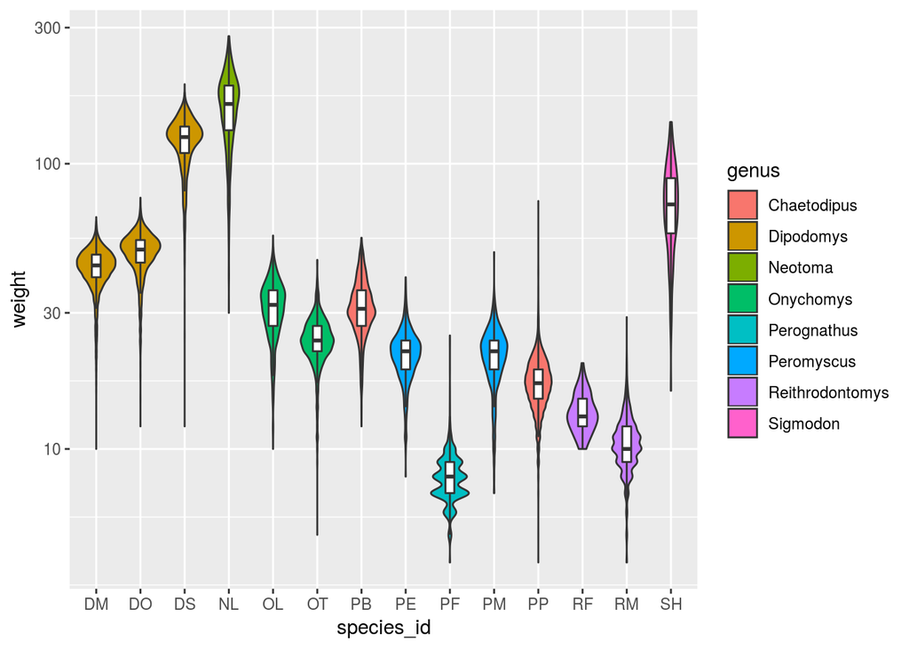

```r
surveys_complete %>%
  ggplot(aes(species_id, weight)) +
  geom_violin(aes(fill = genus)) +
  geom_boxplot(width = 0.2, outlier.shape = NA) +
  scale_y_log10()
```

## 3.2 Two categorical variables

Use the `count()` function to get the number of individuals of each genus in each plot type surveyed and then use that table to make a visual representation like the one shown below.

(hint: try the `size` aesthetic with `geom_point()`)

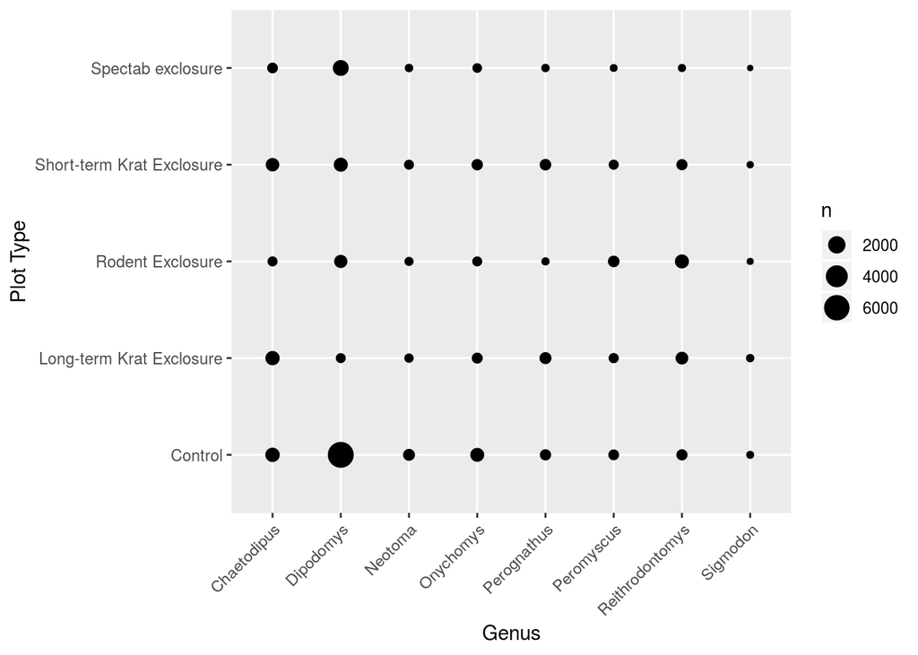

```r
surveys_complete %>%
  count(genus, plot_type) %>%
  ggplot(aes(genus, plot_type)) +
  geom_point(aes(size = n)) +
  theme(axis.text.x = element_text(angle = 45, hjust = 1)) +
  labs(x = "Genus", y = "Plot Type")
```

## 3.3 Line plots

We want to explore if the species diversity (number of different species) changed across the years in different plot treatments (`plot_type`).

- Make a new table called `yearly_diversity`, with the number of *distinct* `species_id` sampled in each year and plot type.

(hint: use the function `n_distinct()` inside the `summarise()` function)

```r
yearly_diversity <- surveys_complete %>%
  group_by(year, plot_type) %>%
  summarise(n_species = n_distinct(species_id)) %>%
  ungroup()
```

- Using the new table, try and reproduce the plot below

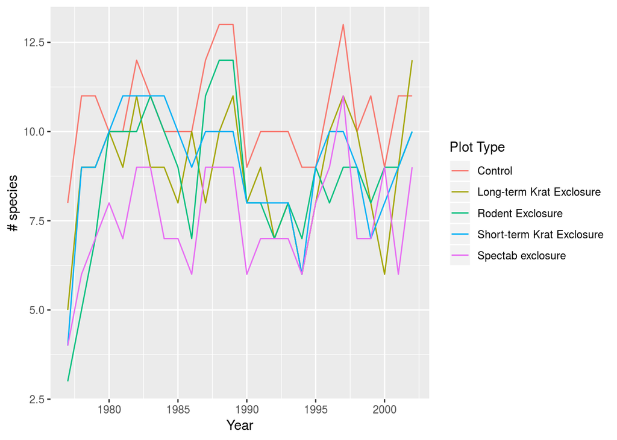

```r
yearly_diversity %>%
  ggplot(aes(year, n_species)) +
  geom_line(aes(colour = plot_type)) +
  labs(colour = "Plot Type", x = "Year", y = "# species")
```

- Update your summary table by also including information about sex (i.e. species diversity per `year`, `plot_type` and `sex`). Can you think of ways to change your previous plot to also visualise this extra information?

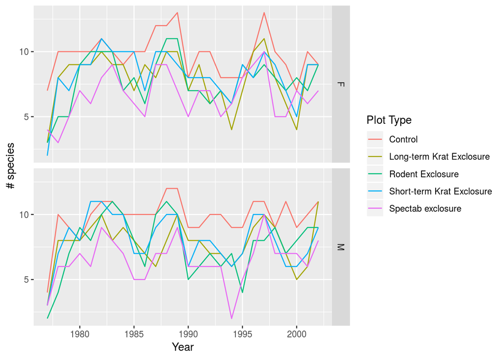

## 3.4 Factors to improve visualisation

- Using your `yearly_diversity` table, can you recreate the plot below, ensuring the order of the `plot_type` facets is as shown?

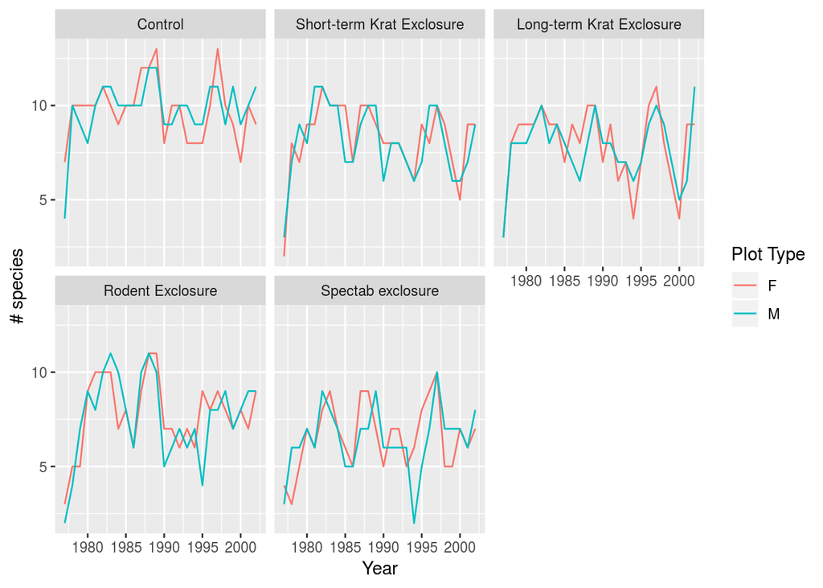

```r
# Make a vector with treatments in desired order
## this is optional, but makes it easier to read the code
plot_type_order <- c("Control",
                     "Short-term Krat Exclosure", "Long-term Krat Exclosure",
                     "Rodent Exclosure", "Spectab exclosure")

# Factorise the `plot_type` variable with custom levels before plotting
yearly_diversity %>%
  mutate(plot_type = factor(plot_type, levels = plot_type_order)) %>%
  ggplot(aes(year, n_species)) +
  geom_line(aes(colour = sex)) +
  labs(colour = "Plot Type", x = "Year", y = "# species") +
  facet_wrap( ~ plot_type)
```

# 4 Optional (advanced) plotting exercises

## 4.1 Line plots

Use line plots to help you explore these questions:

- How did the average weight of all species change across the years?

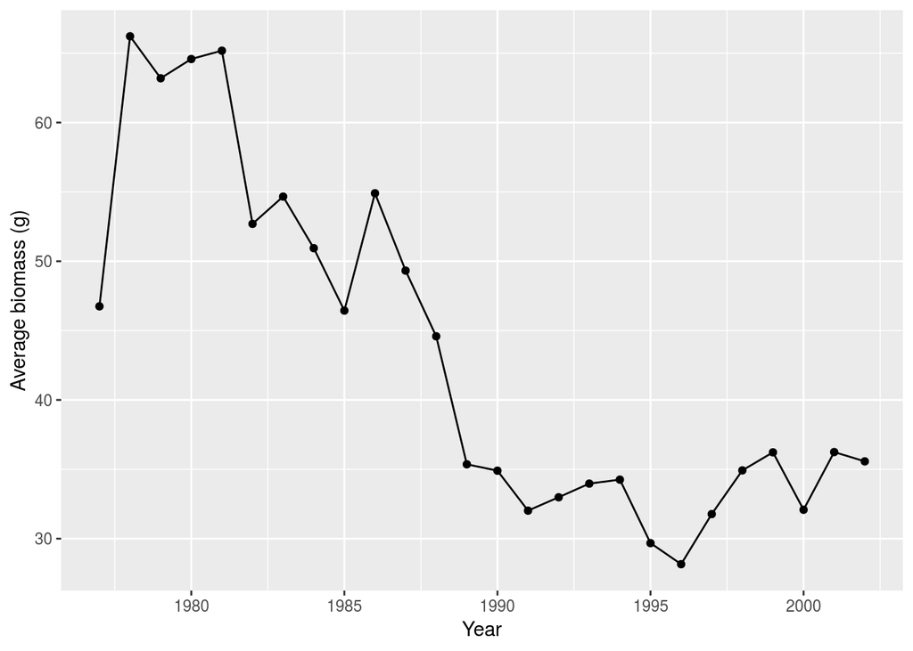

```r
surveys_complete %>%
  group_by(year) %>%
  summarise(mean_wgt = mean(weight, na.rm = TRUE)) %>%
  ggplot(aes(year, mean_wgt)) +
  geom_line() + geom_point() +
  labs(x = "Year", y = "Average biomass (g)")
```

- Was it different for males and females?

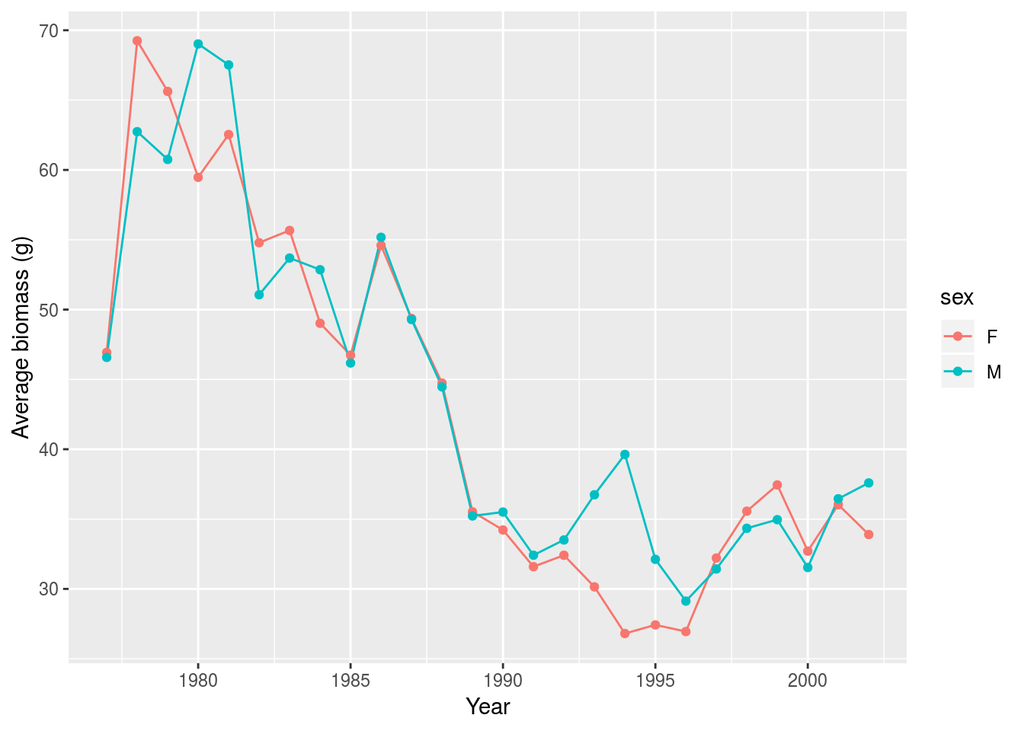

```r
surveys_complete %>%
  group_by(year, sex) %>%
  summarise(mean_wgt = mean(weight, na.rm = TRUE)) %>%
  ggplot(aes(year, mean_wgt, colour = sex)) +
  geom_line() + geom_point() +
  labs(x = "Year", y = "Average biomass (g)")
```

- What about between different `plot_type`? (hint: use facetting to help you)

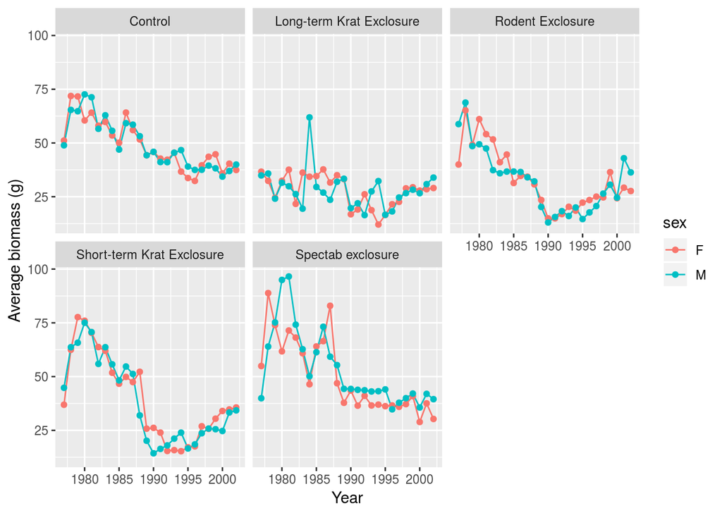

```r
surveys_complete %>%
  group_by(year, sex, plot_type) %>%
  summarise(mean_wgt = mean(weight, na.rm = TRUE)) %>%
  ggplot(aes(year, mean_wgt, colour = sex)) +
  geom_line() + geom_point() +
  facet_wrap(~ plot_type) +
  labs(x = "Year", y = "Average biomass (g)")
```

- Bonus: Try and add a “ribbon” which shows the mean +/- 2*SEM (standard error of the mean, calculated as the standard deviation divided by the square root of the number of observations)

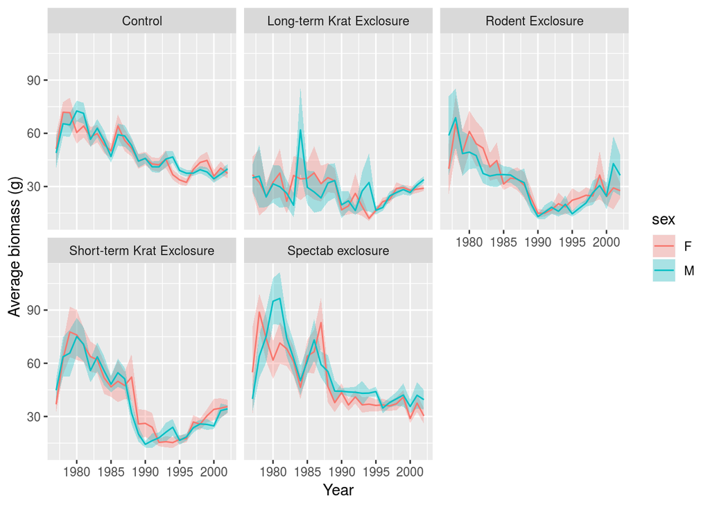

```r
surveys_complete %>%
  group_by(year, sex, plot_type) %>%
  summarise(mean_wgt = mean(weight),
            se_wgt = sd(weight)/sqrt(n())) %>%
  ggplot(aes(year, mean_wgt, colour = sex)) +
  geom_ribbon(aes(ymin = mean_wgt - 2*se_wgt, ymax = mean_wgt + 2*se_wgt, fill = sex),
              alpha = 0.3, colour = NA) +
  geom_line() +
  facet_wrap( ~ plot_type) +
  labs(x = "Year", y = "Average biomass (g)")
```

## 4.2 Reshaping data

- Make a scatterplot to explore the correlation between average male and female weights per species in each `plot_type` surveyed. (hint: add a x=y identity line using `geom_abline()`)

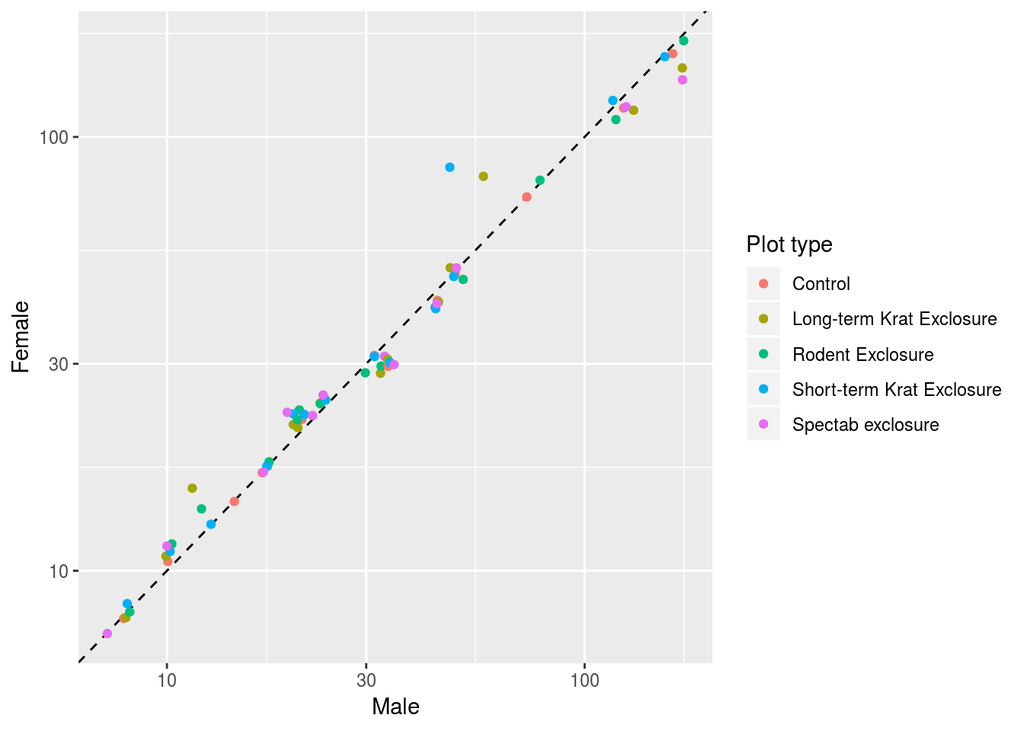

```r
surveys_complete %>%
  group_by(species_id, plot_type, sex) %>%
  summarise(mean_wgt = mean(weight)) %>%
  ungroup() %>%
  spread(sex, mean_wgt) %>%
  ggplot(aes(M, F)) +
  geom_abline(linetype = 2) +
  geom_point(aes(colour = factor(plot_type))) +
  scale_x_log10() + scale_y_log10() +
  labs(x = "Male", y = "Female", colour = "Plot type")
```

## 4.3 Reordering factors

- Make a boxplot similar to the one below, showing the hindfoot length distribution, with the x-axis sorted by mean weight. (hint: create a colum with the mean weight per species and then use the function `reorder()` to factorise the x-axis variable)

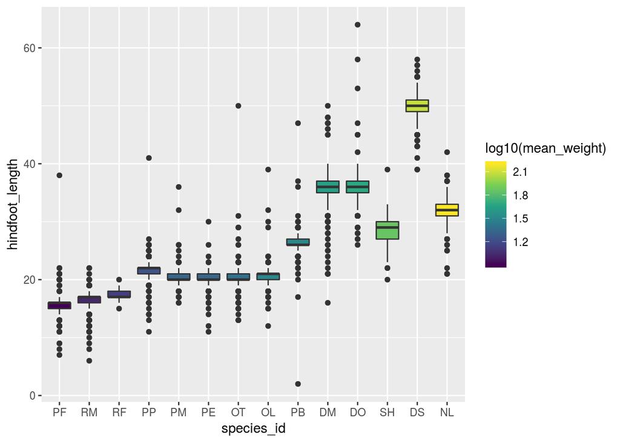

```r
surveys_complete %>%
  group_by(species_id) %>%
  mutate(mean_weight = mean(weight)) %>%
  ungroup() %>%
  mutate(species_id = reorder(species_id, mean_weight)) %>%
  ggplot(aes(species_id, hindfoot_length)) +
  geom_boxplot(aes(fill = log10(mean_weight))) +
  scale_fill_viridis_c() # "viridis" is a colour-blind pallete
```

## 4.4 Combining datasets

In a publication from [Ernest et al. 2017](https://www.journals.uchicago.edu/doi/10.1086/592402) some species where classified according to their habitat preferences.

Read this information into your R session using the following command:

```
habitat_pref <- read_csv("https://raw.githubusercontent.com/tavareshugo/data_carpentry_extras/master/slides_with_exercises/species_habitat_affinities_Ernest2017.csv")
```

- How many of these species are contained in your `surveys_complete` dataset? (hint: the function `paste()` might be useful)

```r
sum(habitat_pref$species %in% paste(surveys_complete$genus, surveys_complete$species))
```

- Make a boxplot like the one below, showing the weight distribution of each species that has habitat affinity information. (hint: look at the help for `?facet_grid` to see how to make the panels scales and spacing adjust to the data)

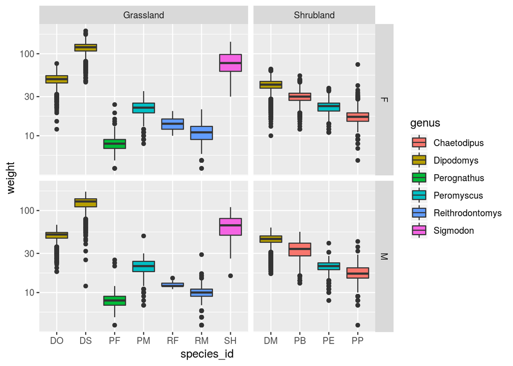

```r
surveys_complete %>%
  mutate(species_name = paste(genus, species)) %>%
  inner_join(habitat_pref, by = c("species_name" = "species")) %>%
  ggplot(aes(species_id, weight)) +
  geom_boxplot(aes(fill = genus)) +
  facet_grid(sex ~ habitat, scale = "free_x", space = "free_x") +
  scale_y_log10()
```

- Plot the change in abundance across the years for species with different habitat affinities (include those species with no habitat information as well).
  - Abundance = number of individuals per hectare
  - Each plot is 0.25ha

(don’t worry too much about getting the exact look of the graph below. But if you do want to get a similar look, try and do some web search! E.g. “how to change legend position in ggplot2”)

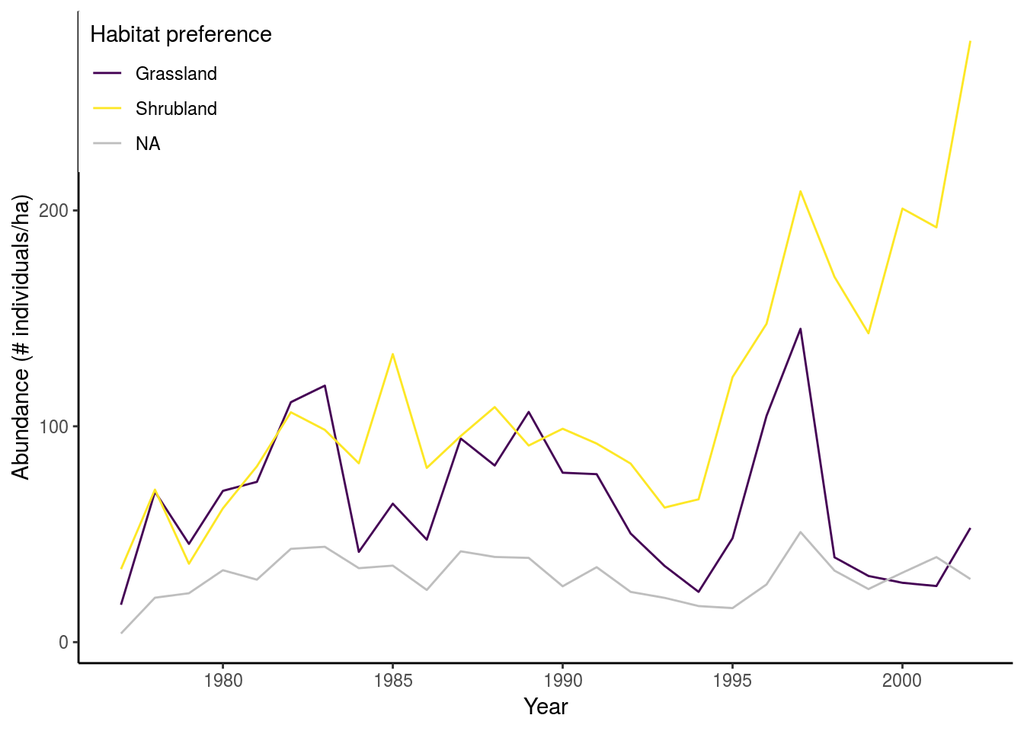

```r
surveys_complete %>%
  mutate(species_name = paste(genus, species)) %>%
  left_join(habitat_pref, by = c("species_name" = "species")) %>%
  group_by(year, habitat) %>%
  summarise(abundance = n()/(0.25*n_distinct(plot_id))) %>%
  ggplot(aes(year, abundance)) +
  geom_line(aes(colour = habitat)) +
  labs(x = "Year", y = "Abundance (# individuals/ha)", colour = "Habitat preference") +
  scale_colour_viridis_d(na.value = "grey") +
  theme_classic() +
  theme(legend.position = c(0, 1), legend.justification = c(0, 1))
```